# Materials towards Homework 5: PVI with XGBoost

Part of the **eXplainable Machine Learning** course for Machine Learning (MSc) studies at the University of Warsaw. [@pbiecek](https://github.com/pbiecek) [@hbaniecki](https://github.com/hbaniecki)

v0.1.0: 2022-11-16

https://github.com/mim-uw/eXplainableMachineLearning-2023/tree/main/Homeworks/HW5

## 0. Import packages

```python
import dalex as dx
import xgboost
import shap

import sklearn

import pandas as pd
import numpy as np

import warnings
warnings.filterwarnings("ignore")

import platform
print(f'Python {platform.python_version()}')

{package.__name__: package.__version__ for package in [dx, xgboost, shap, sklearn, pd, np]}
```

```
Python 3.9.2
```

```
{'dalex': '1.5.0',
 'xgboost': '1.6.2',
 'shap': '0.41.0',
 'sklearn': '1.1.3',
 'pandas': '1.3.5',
 'numpy': '1.23.4'}
```

We use the same XGBoost classifier trained on the Titanic dataset as in the previous materials towards [Homework 2](https://mim-uw.github.io/eXplainableMachineLearning-2023/hw2_shap_with_xgboost_on_titanic.html), [Homework 3](https://mim-uw.github.io/eXplainableMachineLearning-2023/hw3_lime_with_xgboost_on_titanic.html) \& [Homework 4](https://mim-uw.github.io/eXplainableMachineLearning-2023/hw4_cp_and_pdp_with_xgboost_on_titanic.html).

## 1. Load and preprocess data

```python
df = dx.datasets.load_titanic()

df.loc[:, df.dtypes == 'object'] =\
    df.select_dtypes(['object'])\
    .apply(lambda x: x.astype('category'))

X = df.drop(columns='survived')
# convert gender to binary only because the `max_cat_to_onehot` parameter in XGBoost is yet to be working properly..
X =  pd.get_dummies(X, columns=["gender"], drop_first=True)
y = df.survived

X_train, X_test, y_train, y_test = sklearn.model_selection.train_test_split(X, y, test_size=0.33, random_state=42)
```

## 2. Model

```python
model = xgboost.XGBClassifier(
    n_estimators=50,
    max_depth=2,
    use_label_encoder=False,
    eval_metric="logloss",

    enable_categorical=True,
    tree_method="hist"
)

model.fit(X_train, y_train)
```

```
XGBClassifier(base_score=0.5, booster='gbtree', callbacks=None,
              colsample_bylevel=1, colsample_bynode=1, colsample_bytree=1,
              early_stopping_rounds=None, enable_categorical=True,
              eval_metric='logloss', gamma=0, gpu_id=-1,
              grow_policy='depthwise', importance_type=None,
              interaction_constraints='', learning_rate=0.300000012,
              max_bin=256, max_cat_to_onehot=4, max_delta_step=0, max_depth=2,
              max_leaves=0, min_child_weight=1, missing=nan,
              monotone_constraints='()', n_estimators=50, n_jobs=0,
              num_parallel_tree=1, predictor='auto', random_state=0,
              reg_alpha=0, reg_lambda=1, ...)
```

```python
def pf_xgboost_classifier_categorical(model, df):
    df.loc[:, df.dtypes == 'object'] =\
        df.select_dtypes(['object'])\
        .apply(lambda x: x.astype('category'))
    return model.predict_proba(df)[:, 1]

explainer = dx.Explainer(model, X_test, y_test, predict_function=pf_xgboost_classifier_categorical)
```

```
Preparation of a new explainer is initiated

  -> data              : 729 rows 7 cols
  -> target variable   : Parameter 'y' was a pandas.Series. Converted to a numpy.ndarray.
  -> target variable   : 729 values
  -> model_class       : xgboost.sklearn.XGBClassifier (default)
  -> label             : Not specified, model's class short name will be used. (default)
  -> predict function  : <function pf_xgboost_classifier_categorical at 0x000001D3817B2CA0> will be used
  -> predict function  : Accepts only pandas.DataFrame, numpy.ndarray causes problems.
  -> predicted values  : min = 0.0258, mean = 0.333, max = 0.99
  -> model type        : classification will be used (default)
  -> residual function : difference between y and yhat (default)
  -> residuals         : min = -0.987, mean = -0.00781, max = 0.936
  -> model_info        : package xgboost

A new explainer has been created!
```

## 3. Evaluate!

```python
explainer.model_performance()
```

|  | recall | precision | f1 | accuracy | auc |
| --- | --- | --- | --- | --- | --- |
| XGBClassifier | 0.582278 | 0.730159 | 0.647887 | 0.794239 | 0.809509 |

### Permutation-based Variable Importance

See the API documentation for all the possible values of the specific parameters:

- [`Explainer.model_parts()`](https://dalex.drwhy.ai/python/api/index.html#dalex.Explainer.model_parts), which returns an object of class
- [`VariableImportance`](https://dalex.drwhy.ai/python/api/model_explanations/index.html#dalex.model_explanations.VariableImportance), which can be visualized using
- [`VariableImportance.plot()`](https://dalex.drwhy.ai/python/api/model_explanations/index.html#dalex.model_explanations.VariableImportance.plot).

```python
pvi = explainer.model_parts(random_state=0)
```

```python
pvi.result
```

|  | variable | dropout_loss | label |
| --- | --- | --- | --- |
| 0 | parch | 0.189701 | XGBClassifier |
| 1 | _full_model_ | 0.190491 | XGBClassifier |
| 2 | embarked | 0.195568 | XGBClassifier |
| 3 | sibsp | 0.197910 | XGBClassifier |
| 4 | fare | 0.198708 | XGBClassifier |
| 5 | age | 0.240732 | XGBClassifier |
| 6 | class | 0.285486 | XGBClassifier |
| 7 | gender_male | 0.378925 | XGBClassifier |
| 8 | _baseline_ | 0.510619 | XGBClassifier |

```python
pvi.plot(show=False).update_layout(autosize=False, width=600, height=450)
```

[interactive chart not shown]

```python
pvi.plot(
    max_vars=3,
    digits=4,
    bar_width=40,
    title="Permutation-based Variable Importance (Top 3)",
    show=False
).update_layout(width=600)
```

[interactive chart not shown]

PVI depends on the **loss function** used for drop-out computation.

For binary classification, it's `1-AUC` by default.

```
def loss_one_minus_auc(observed, predicted):
    return 1 - auc(y_true=observed, y_pred=predicted)
```

Let's create our own loss function for comparison.

```python
def loss_one_minus_acc(observed, predicted, th=0.5):
    predicted_class = predicted > th
    acc = np.mean(observed == predicted_class)
    return 1 - acc
```

```python
pvi_acc = explainer.model_parts(
    loss_function=loss_one_minus_acc,
    label="XGBoost [loss 1-ACC]",
    random_state=0
)
```

```python
pvi.plot(
    pvi_acc,
    max_vars=6,
    title="Permutation-based Variable Importance (Top 6)",
    show=False
).update_layout(width=600)
```

[interactive chart not shown]

In this case, the ranking diverges only at the 6th most important variable.

In many cases, it is more beneficial to report the ratio of variable importance relative to the baseline value.

```python
pvi_ratio = explainer.model_parts(
    type="ratio",
    label="XGBoost [loss 1-AUC]",
    random_state=0
)
pvi_acc_ratio = explainer.model_parts(
    type="ratio",
    loss_function=loss_one_minus_acc,
    label="XGBoost [loss 1-ACC]",
    random_state=0
)
```

```python
pvi_ratio.plot(
    pvi_acc_ratio,
    title="Comparison of perm-based VI ratios for different loss functions",
    show=False
).update_layout(width=900)
```

[interactive chart not shown]

Note that the variables in both plots are in the same order, which is based on their average importance.

When there are many variables and/or they are correlated, we might be interested in grouping them together for calculating variable importance.

```python
pvi_grouped = explainer.model_parts(
    variable_groups={
        'personal': ['gender_male', 'age', 'sibsp', 'parch'],
        'wealth': ['class', 'fare']
    }, random_state=0)
```

```python
pvi_grouped.plot(
    title="Grouped Permutation-based Variable Importance",
    show=False
).update_layout(autosize=False, width=600, height=250)
```

[interactive chart not shown]

Last but not least, one can increase the `N` and `B` parameters for lower estimation error, at a cost computation time.

```python
pvi_accurate = explainer.model_parts(N=None, B=25, random_state=0) # None means all data
```

```python
pd.concat([
    pvi_accurate.result.drop("label", axis=1).set_index("variable").rename(columns={"dropout_loss": "accurate PVI"}),
    pvi.result.drop("label", axis=1).set_index("variable").rename(columns={"dropout_loss": "default PVI"})
], axis=1)
```

| variable | accurate PVI | default PVI |
| --- | --- | --- |
| parch | 0.189974 | 0.189701 |
| _full_model_ | 0.190491 | 0.190491 |
| embarked | 0.193976 | 0.195568 |
| sibsp | 0.197059 | 0.197910 |
| fare | 0.199214 | 0.198708 |
| age | 0.242790 | 0.240732 |
| class | 0.279159 | 0.285486 |
| gender_male | 0.378469 | 0.378925 |
| _baseline_ | 0.493551 | 0.510619 |

### Gini-based Variable Importance

Tree-based models have variable importance measured by-design.

Many widely-used implementations provide attributes like `feature_importances_`.

```python
model.feature_importances_
```

```
array([0.05879982, 0.1634799 , 0.04673264, 0.04072754, 0.05098921,
       0.02352506, 0.6157458 ], dtype=float32)
```

```python
pd.DataFrame({'variable': X_test.columns, 'importance': model.feature_importances_})
```

|  | variable | importance |
| --- | --- | --- |
| 0 | age | 0.058800 |
| 1 | class | 0.163480 |
| 2 | embarked | 0.046733 |
| 3 | fare | 0.040728 |
| 4 | sibsp | 0.050989 |
| 5 | parch | 0.023525 |
| 6 | gender_male | 0.615746 |

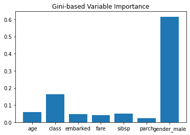

```python
import matplotlib.pyplot as plt
plt.bar(X_test.columns, model.feature_importances_)
plt.title("Gini-based Variable Importance")
plt.show()
```

### SHAP-based Variable Importance

See the API documentation for all the possible values of the specific parameters:

- [`Explainer.model_parts(type="shap_wrapper")`](https://dalex.drwhy.ai/python/api/index.html#dalex.Explainer.model_parts), which returns an object of class
- [`ShapWrapper`](https://dalex.drwhy.ai/python/api/wrappers/index.html#dalex.wrappers.ShapWrapper), which can be visualized using
- [`ShapWrapper.plot()`](https://dalex.drwhy.ai/python/api/wrappers/index.html#dalex.wrappers.ShapWrapper.plot).

and API of the [`shap`](https://github.com/slundberg/shap) package.

Unfortunately, TreeSHAP works only with numerical variables.

```python
X_ohe = pd.get_dummies(X, columns=['class', 'embarked'], drop_first=True)

model_ohe = xgboost.XGBClassifier(
    n_estimators=100,
    max_depth=3,
    use_label_encoder=False,
    eval_metric="logloss"
)

X_ohe_train, X_ohe_test, y_ohe_train, y_ohe_test =\
    sklearn.model_selection.train_test_split(X_ohe, y, test_size=0.33, random_state=42)

model_ohe.fit(X_ohe_train, y_ohe_train)

explainer_ohe = dx.Explainer(model_ohe, X_ohe_test, y_ohe_test, label="XGBoost with OHE")
```

```
Preparation of a new explainer is initiated

  -> data              : 729 rows 14 cols
  -> target variable   : Parameter 'y' was a pandas.Series. Converted to a numpy.ndarray.
  -> target variable   : 729 values
  -> model_class       : xgboost.sklearn.XGBClassifier (default)
  -> label             : XGBoost with OHE
  -> predict function  : <function yhat_proba_default at 0x000001D3E59D7700> will be used (default)
  -> predict function  : Accepts pandas.DataFrame and numpy.ndarray.
  -> predicted values  : min = 0.00631, mean = 0.336, max = 1.0
  -> model type        : classification will be used (default)
  -> residual function : difference between y and yhat (default)
  -> residuals         : min = -0.999, mean = -0.0106, max = 0.98
  -> model_info        : package xgboost

A new explainer has been created!
```

```python
shap_vi = explainer_ohe.model_parts(type="shap_wrapper", shap_explainer_type="TreeExplainer")
```

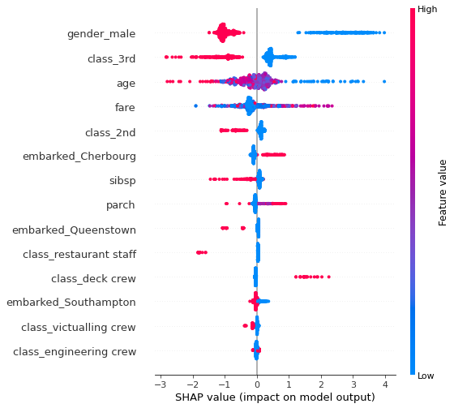

```python
shap_vi.plot()
```

# For a theoretical introduction and more examples, see: https://ema.drwhy.ai